# Product-Level Profitability & Revenue Optimization Analysis

Olist Brazilian E-Commerce Dataset

Author

Mutkallam Warraich

# 1 Executive Summary

- Total baseline profit was $2.40M
- A 10% reduction in freight costs increased profit by $217K (+9.06%)
- Profit is highly concentrated in a small number of categories (Pareto effect)
- Several transactions operate at negative margins, indicating inefficiencies in pricing or cost structure

# 2 Key Business Insights

- A small group of product categories drives the majority of profit
- Freight costs have a material impact on profitability
- Low-margin and negative-margin orders present an opportunity for optimization
- Pricing and cost control are the primary levers for improving profitability

# 3 Recommendations

- Optimize logistics to reduce freight costs (high ROI lever)
- Identify and adjust pricing for low-margin or loss-making products
- Focus inventory and marketing efforts on top-performing categories
- Implement margin monitoring at the SKU level

# 4 Code

## 4.1 Data Preparation

This section loads and prepares the datasets used for analysis.

```r
library(tidyverse)
library(janitor)
library(lubridate)

# Load datasets
order_items <- read_csv("data/raw/olist_order_items_dataset.csv") |> clean_names()
orders      <- read_csv("data/raw/olist_orders_dataset.csv") |> clean_names()
products    <- read_csv("data/raw/olist_products_dataset.csv") |> clean_names()
customers   <- read_csv("data/raw/olist_customers_dataset.csv") |> clean_names()
```

```r
names(order_items)
```

```
[1] "order_id"            "order_item_id"       "product_id"
[4] "seller_id"           "shipping_limit_date" "price"
[7] "freight_value"
```

```r
names(orders)
```

```
[1] "order_id"                      "customer_id"
[3] "order_status"                  "order_purchase_timestamp"
[5] "order_approved_at"             "order_delivered_carrier_date"
[7] "order_delivered_customer_date" "order_estimated_delivery_date"
```

```r
names(products)
```

```
[1] "product_id"                 "product_category_name"
[3] "product_name_lenght"        "product_description_lenght"
[5] "product_photos_qty"         "product_weight_g"
[7] "product_length_cm"          "product_height_cm"
[9] "product_width_cm"
```

```r
names(customers)
```

```
[1] "customer_id"              "customer_unique_id"
[3] "customer_zip_code_prefix" "customer_city"
[5] "customer_state"
```

## 4.2 Data Integration

This step combines multiple datasets into a unified order-level dataset for analysis.

```r
master_orders <- order_items %>%
  left_join(
    orders %>%
      select(
        order_id,
        customer_id,
        order_status,
        order_purchase_timestamp,
        order_delivered_customer_date
      ),
    by = "order_id"
  ) %>%
  left_join(
    products %>%
      select(
        product_id,
        product_category_name
      ),
    by = "product_id"
  ) %>%
  left_join(
    customers %>%
      select(
        customer_id,
        customer_city,
        customer_state
      ),
    by = "customer_id"
  )
```

```r
glimpse(master_orders)
```

```
Rows: 112,650
Columns: 14
$ order_id                      <chr> "00010242fe8c5a6d1ba2dd792cb16214", "000…
$ order_item_id                 <dbl> 1, 1, 1, 1, 1, 1, 1, 1, 1, 1, 1, 1, 1, 1…
$ product_id                    <chr> "4244733e06e7ecb4970a6e2683c13e61", "e5f…
$ seller_id                     <chr> "48436dade18ac8b2bce089ec2a041202", "dd7…
$ shipping_limit_date           <dttm> 2017-09-19 09:45:35, 2017-05-03 11:05:1…
$ price                         <dbl> 58.90, 239.90, 199.00, 12.99, 199.90, 21…
$ freight_value                 <dbl> 13.29, 19.93, 17.87, 12.79, 18.14, 12.69…
$ customer_id                   <chr> "3ce436f183e68e07877b285a838db11a", "f6d…
$ order_status                  <chr> "delivered", "delivered", "delivered", "…
$ order_purchase_timestamp      <dttm> 2017-09-13 08:59:02, 2017-04-26 10:53:0…
$ order_delivered_customer_date <dttm> 2017-09-20 23:43:48, 2017-05-12 16:04:2…
$ product_category_name         <chr> "cool_stuff", "pet_shop", "moveis_decora…
$ customer_city                 <chr> "campos dos goytacazes", "santa fe do su…
$ customer_state                <chr> "RJ", "SP", "MG", "SP", "SP", "MG", "SP"…
```

## 4.3 Data Cleaning

This step filters the dataset to include only valid completed transactions.

```r
master_orders_clean <- master_orders %>%
  filter(order_status == "delivered") %>%
  filter(!is.na(price), !is.na(freight_value), !is.na(product_category_name))

glimpse(master_orders_clean)
```

```
Rows: 108,660
Columns: 14
$ order_id                      <chr> "00010242fe8c5a6d1ba2dd792cb16214", "000…
$ order_item_id                 <dbl> 1, 1, 1, 1, 1, 1, 1, 1, 1, 1, 1, 1, 1, 1…
$ product_id                    <chr> "4244733e06e7ecb4970a6e2683c13e61", "e5f…
$ seller_id                     <chr> "48436dade18ac8b2bce089ec2a041202", "dd7…
$ shipping_limit_date           <dttm> 2017-09-19 09:45:35, 2017-05-03 11:05:1…
$ price                         <dbl> 58.90, 239.90, 199.00, 12.99, 199.90, 21…
$ freight_value                 <dbl> 13.29, 19.93, 17.87, 12.79, 18.14, 12.69…
$ customer_id                   <chr> "3ce436f183e68e07877b285a838db11a", "f6d…
$ order_status                  <chr> "delivered", "delivered", "delivered", "…
$ order_purchase_timestamp      <dttm> 2017-09-13 08:59:02, 2017-04-26 10:53:0…
$ order_delivered_customer_date <dttm> 2017-09-20 23:43:48, 2017-05-12 16:04:2…
$ product_category_name         <chr> "cool_stuff", "pet_shop", "moveis_decora…
$ customer_city                 <chr> "campos dos goytacazes", "santa fe do su…
$ customer_state                <chr> "RJ", "SP", "MG", "SP", "SP", "MG", "SP"…
```

## 4.4 Profitability Framework

These will have all the key financial metrics including revenue, cost, profit, and margin being calculated.

```r
master_orders_clean <- master_orders_clean %>%
  mutate(
    revenue = price,
    total_cost = 0.65 * price + freight_value,   # assumed 65% cost
    gross_profit = revenue - total_cost,
    margin_pct = gross_profit / revenue
  )

glimpse(master_orders_clean)
```

```
Rows: 108,660
Columns: 18
$ order_id                      <chr> "00010242fe8c5a6d1ba2dd792cb16214", "000…
$ order_item_id                 <dbl> 1, 1, 1, 1, 1, 1, 1, 1, 1, 1, 1, 1, 1, 1…
$ product_id                    <chr> "4244733e06e7ecb4970a6e2683c13e61", "e5f…
$ seller_id                     <chr> "48436dade18ac8b2bce089ec2a041202", "dd7…
$ shipping_limit_date           <dttm> 2017-09-19 09:45:35, 2017-05-03 11:05:1…
$ price                         <dbl> 58.90, 239.90, 199.00, 12.99, 199.90, 21…
$ freight_value                 <dbl> 13.29, 19.93, 17.87, 12.79, 18.14, 12.69…
$ customer_id                   <chr> "3ce436f183e68e07877b285a838db11a", "f6d…
$ order_status                  <chr> "delivered", "delivered", "delivered", "…
$ order_purchase_timestamp      <dttm> 2017-09-13 08:59:02, 2017-04-26 10:53:0…
$ order_delivered_customer_date <dttm> 2017-09-20 23:43:48, 2017-05-12 16:04:2…
$ product_category_name         <chr> "cool_stuff", "pet_shop", "moveis_decora…
$ customer_city                 <chr> "campos dos goytacazes", "santa fe do su…
$ customer_state                <chr> "RJ", "SP", "MG", "SP", "SP", "MG", "SP"…
$ revenue                       <dbl> 58.90, 239.90, 199.00, 12.99, 199.90, 21…
$ total_cost                    <dbl> 51.5750, 175.8650, 147.2200, 21.2335, 14…
$ gross_profit                  <dbl> 7.3250, 64.0350, 51.7800, -8.2435, 51.82…
$ margin_pct                    <dbl> 0.12436333, 0.26692372, 0.26020101, -0.6…
```

## 4.5 Category-Level Performance

This section summarizes revenue and profitability across product categories.

```r
category_kpis <- master_orders_clean %>%
  group_by(product_category_name) %>%
  summarise(
    total_revenue = sum(revenue, na.rm = TRUE),
    total_profit = sum(gross_profit, na.rm = TRUE),
    avg_margin = mean(margin_pct, na.rm = TRUE),
    total_orders = n()
  ) %>%
  arrange(desc(total_profit))

category_kpis
```

```
# A tibble: 73 × 5
   product_category_name  total_revenue total_profit avg_margin total_orders
   <chr>                          <dbl>        <dbl>      <dbl>        <int>
 1 relogios_presentes          1166177.      310006.    0.179           5859
 2 beleza_saude                1233132.      252638.    0.0488          9465
 3 esporte_lazer                954853.      170794.    0.0564          8431
 4 informatica_acessorios       888725.      167054.    0.0551          7644
 5 cama_mesa_banho             1023435.      156428.    0.0659         10953
 6 cool_stuff                   610204.      132095.    0.130           3718
 7 automotivo                   578967.      112150.    0.0181          4140
 8 brinquedos                   471286.       89176.    0.0849          4030
 9 perfumaria                   390145.       83524.    0.0780          3340
10 moveis_decoracao             711928.       80772.    0.00407         8160
# ℹ 63 more rows
```

### 4.5.1 Top and Bottom Categories

This section identifies the highest and lowest performing product categories.

```r
top_categories <- category_kpis %>%
  slice_max(total_profit, n = 10)

top_categories
```

```
# A tibble: 10 × 5
   product_category_name  total_revenue total_profit avg_margin total_orders
   <chr>                          <dbl>        <dbl>      <dbl>        <int>
 1 relogios_presentes          1166177.      310006.    0.179           5859
 2 beleza_saude                1233132.      252638.    0.0488          9465
 3 esporte_lazer                954853.      170794.    0.0564          8431
 4 informatica_acessorios       888725.      167054.    0.0551          7644
 5 cama_mesa_banho             1023435.      156428.    0.0659         10953
 6 cool_stuff                   610204.      132095.    0.130           3718
 7 automotivo                   578967.      112150.    0.0181          4140
 8 brinquedos                   471286.       89176.    0.0849          4030
 9 perfumaria                   390145.       83524.    0.0780          3340
10 moveis_decoracao             711928.       80772.    0.00407         8160
```

```r
bottom_categories <- category_kpis %>%
  slice_min(total_profit, n = 10)

bottom_categories
```

```
# A tibble: 10 × 5
   product_category_name      total_revenue total_profit avg_margin total_orders
   <chr>                              <dbl>        <dbl>      <dbl>        <int>
 1 casa_conforto_2                     760.       -144.     -0.584            30
 2 artigos_de_natal                   8738.       -133.     -0.325           150
 3 flores                             1110.       -100.     -0.215            33
 4 moveis_colchao_e_estofado          4323.        -68.2    -0.122            37
 5 fraldas_higiene                    1501.        -20.1    -0.0645           37
 6 cds_dvds_musicais                   730          30.5     0.0380           14
 7 seguros_e_servicos                  283.         57.9     0.202             2
 8 fashion_roupa_infanto_juv…          520.        103.      0.171             7
 9 fashion_esporte                    2095.        170.      0.0378           29
10 artes_e_artesanato                 1814.        265.     -0.0311           24
```

## 4.6 Pareto Analysis

This analysis examines how profit is concentrated across categories.

```r
pareto <- category_kpis %>%
  mutate(
    profit_share = total_profit / sum(total_profit),
    cumulative_profit = cumsum(profit_share)
  )

pareto
```

```
# A tibble: 73 × 7
   product_category_name  total_revenue total_profit avg_margin total_orders
   <chr>                          <dbl>        <dbl>      <dbl>        <int>
 1 relogios_presentes          1166177.      310006.    0.179           5859
 2 beleza_saude                1233132.      252638.    0.0488          9465
 3 esporte_lazer                954853.      170794.    0.0564          8431
 4 informatica_acessorios       888725.      167054.    0.0551          7644
 5 cama_mesa_banho             1023435.      156428.    0.0659         10953
 6 cool_stuff                   610204.      132095.    0.130           3718
 7 automotivo                   578967.      112150.    0.0181          4140
 8 brinquedos                   471286.       89176.    0.0849          4030
 9 perfumaria                   390145.       83524.    0.0780          3340
10 moveis_decoracao             711928.       80772.    0.00407         8160
# ℹ 63 more rows
# ℹ 2 more variables: profit_share <dbl>, cumulative_profit <dbl>
```

### 4.6.1 Pareto Visualization

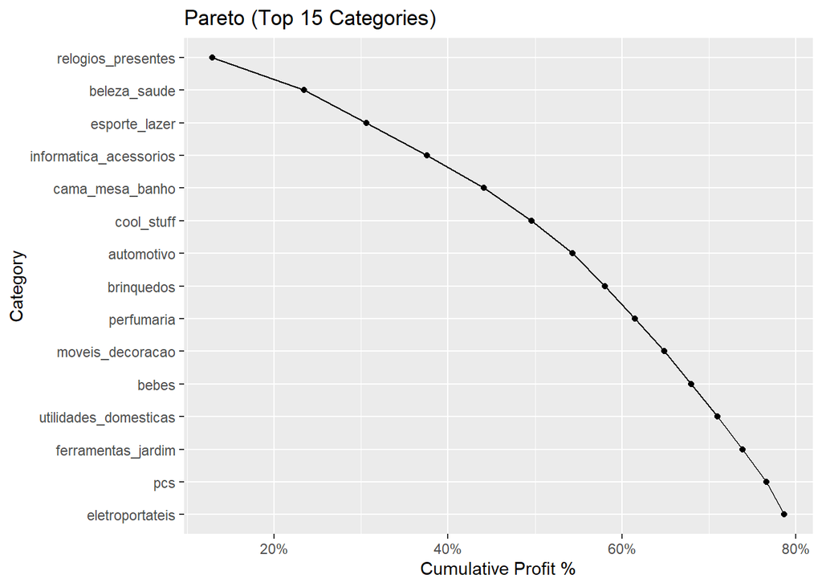

```r
pareto_top <- pareto %>%
  slice_max(total_profit, n = 15)

ggplot(pareto_top, aes(x = reorder(product_category_name, total_profit), y = cumulative_profit)) +
  geom_line(group = 1) +
  geom_point() +
  coord_flip() +
  scale_y_continuous(labels = scales::percent) +
  labs(
    title = "Pareto (Top 15 Categories)",
    x = "Category",
    y = "Cumulative Profit %"
  )
```

## 4.7 Price vs Profit Analysis

This section explores the relationship between pricing and profitability.

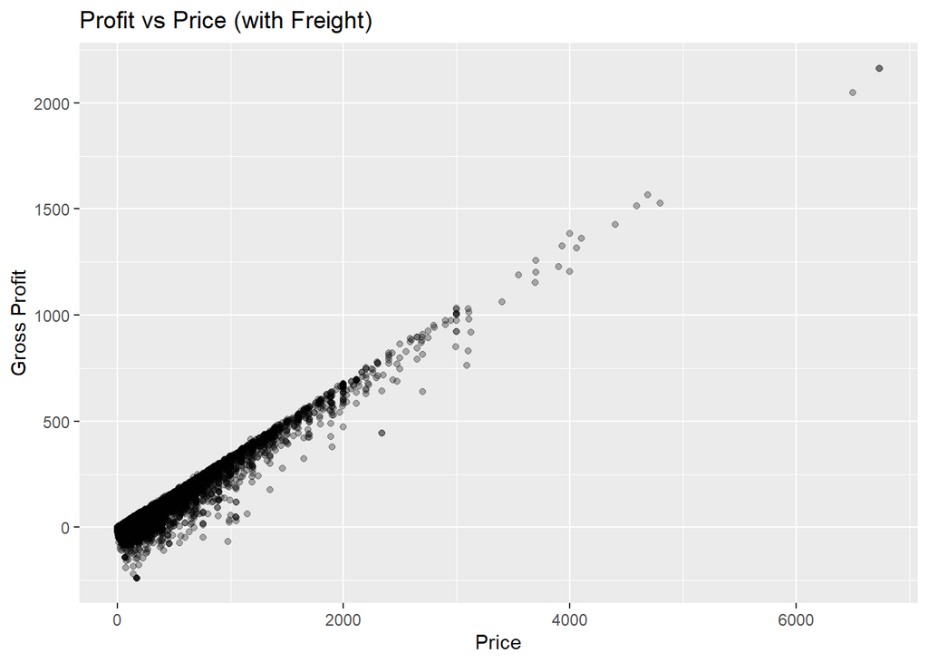

```r
ggplot(master_orders_clean, aes(x = price, y = gross_profit)) +
  geom_point(alpha = 0.3) +
  labs(
    title = "Profit vs Price (with Freight)",
    x = "Price",
    y = "Gross Profit"
  )
```

## 4.8 Margin Distribution

This section shows how profit margins are distributed across transactions.

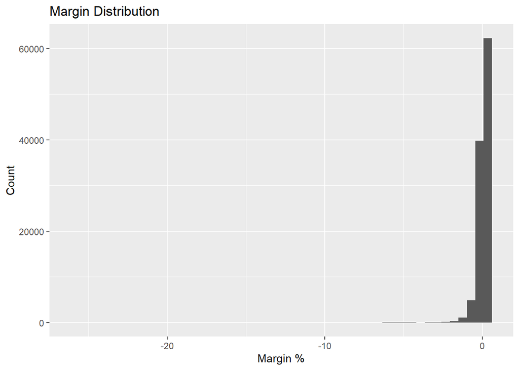

```r
ggplot(master_orders_clean, aes(x = margin_pct)) +
  geom_histogram(bins = 50) +
  labs(
    title = "Margin Distribution",
    x = "Margin %",
    y = "Count"
  )
```

## 4.9 Loss Analysis

This section identifies transactions generating negative profit.

```r
loss_products <- master_orders_clean %>%
  filter(gross_profit < 0)

nrow(loss_products)
```

```
[1] 32437
```

## 4.10 Scenario Analysis

This section simulates the impact of reducing freight costs on profitability.

```r
scenario <- master_orders_clean %>%
  mutate(
    new_cost = 0.65 * price + (freight_value * 0.9),
    new_profit = price - new_cost
  )

# Compare total profit
baseline_profit <- sum(master_orders_clean$gross_profit)
new_profit <- sum(scenario$new_profit)

profit_lift <- new_profit - baseline_profit
profit_lift
```

```
[1] 217130.7
```

```r
profit_lift_pct <- profit_lift / baseline_profit

profit_lift_pct
```

```
[1] 0.09060462
```

## 4.11 Financial Impact Summary

```r
tibble(
  baseline_profit = baseline_profit,
  new_profit = new_profit,
  profit_lift = profit_lift,
  profit_lift_pct = profit_lift_pct
)
```

```
# A tibble: 1 × 4
  baseline_profit new_profit profit_lift profit_lift_pct
            <dbl>      <dbl>       <dbl>           <dbl>
1        2396463.   2613594.     217131.          0.0906
```